# Key findings

Authors

Jolyon Miles-Wilson

Celestin Okoroji

Published

July 12, 2024

# How many people are outsourced?

**1 in 6 (17%) of UK workers are outsourced.**[^1]

In terms of the the different possible types of outsourced groups[^2], the numbers are as follows:

1. Definitely outsourced: 11%
2. Likely agency: 3%
3. High indicators: 3%

# Characteristics of outsourced workers

## Age

Outsourced workers are on average younger than non-outsourced workers. The median age of the outsourced group is 36 , compared to 43 for the not outsourced group.[^3] This difference is statistically significant (*t*(2399.2) = 11.95, *p* = 0).

| Outsourcing group | Mean | Median | Min | Max | Standard dev. | N |
| --- | --- | --- | --- | --- | --- | --- |
| Not outsourced | 42.80 | 43 | 16 | 80 | 13.08 | 8472 |
| Outsourced | 38.63 | 36 | 16 | 78 | 13.07 | 1683 |

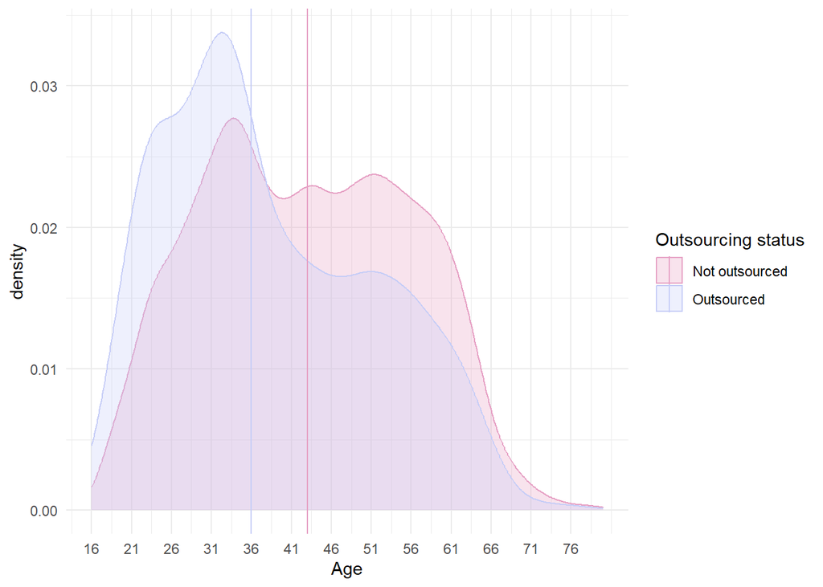

| Outsourcing group | Mean | Median | Min | Max | Standard dev. | N |
| --- | --- | --- | --- | --- | --- | --- |
| Not outsourced | 42.80 | 43 | 16 | 80 | 13.08 | 8472 |
| Outsourced | 38.40 | 35 | 16 | 78 | 13.09 | 1123 |
| Likely agency | 39.80 | 38 | 18 | 77 | 13.49 | 269 |
| High indicators | 38.49 | 35 | 18 | 72 | 12.55 | 291 |

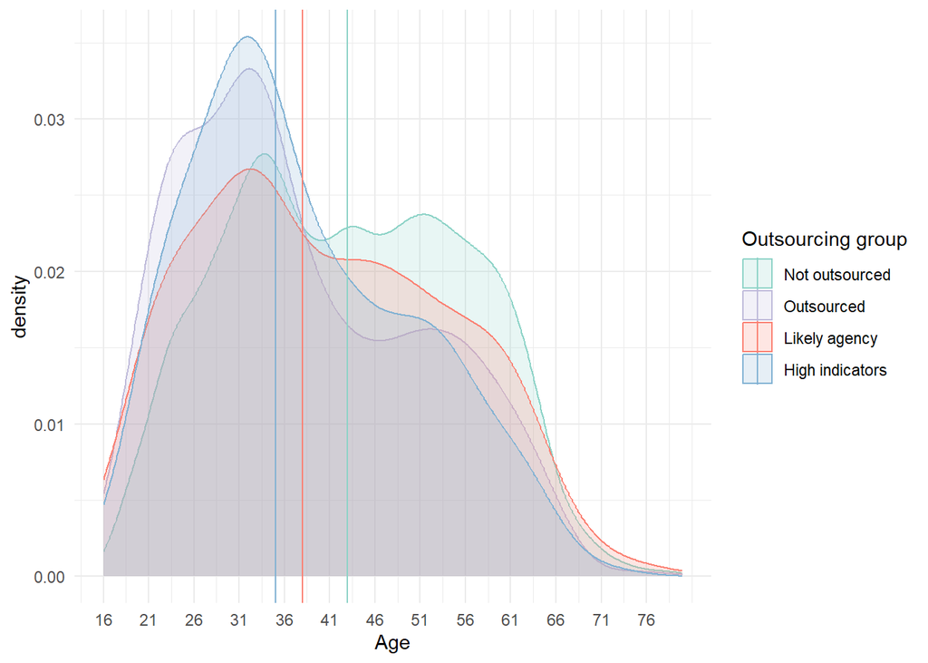

## Gender

The outsourced workforce consists of a greater proportion of males than the non-outsourced workforce.[^5] Men make up 56% of the outsourced workforce compared to 47% of the non-outsourced workforce. This difference is statistically significant; outsourced workers, compared to non-outsourced workers, are 1.44 times more likely to be male than female.[^6]

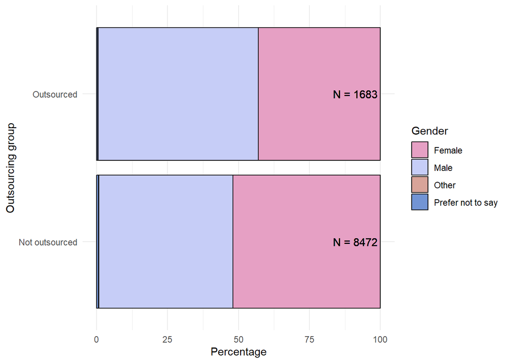

Breaking down by outsourcing group, we find that the group with the largest proportion of men in the workforce is the ‘high indicators’ group (66.35%), followed by the ‘likely agency’ group (56.66%), followed by the ‘outsourced’ group (53.94%). Statistically speaking, compared to a not outsourced person,

- Someone in the high indicators group is 2.18 times more likely to be male than female.
- Someone in the likely agency group is 1.45 times more likely tobe male than female.
- Someone in the outsourced group is 1.31 times more likely tobe male than female.

Additionally, people identifying as ‘Other’ gender are absent from the high indicators and likely agency groups, though given the small N (14) for this group, this finding is unlikely to be meaningful.

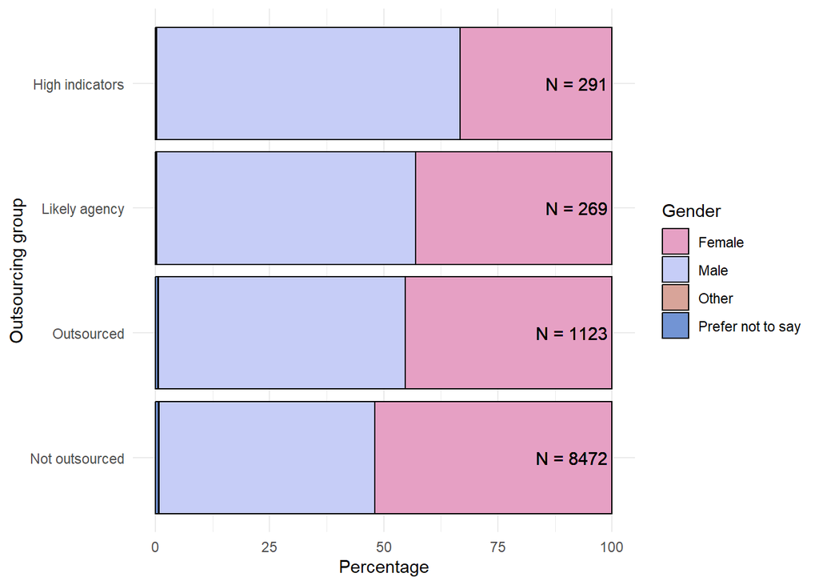

## Ethnicity

People from an ethnic minority are 1.83 times more likely to be outsourced than people from a White British background; 33.09% of outsourced workers are from an ethnic minority, compared to 21.99% of non-outsourced workers.[^7]

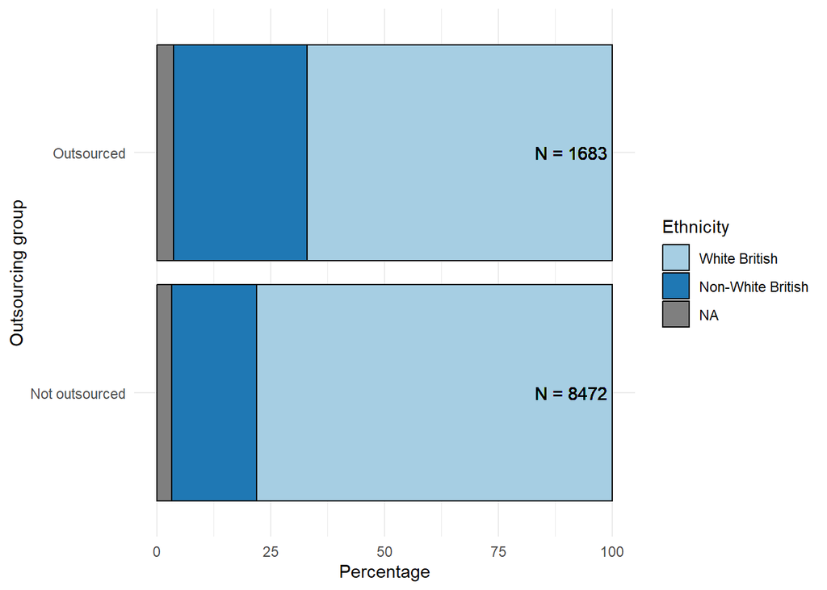

Comparison of ethnicities indicates that some groups are statistically more likely to be outsourced than others[^8]:

- White other workers are 1.43 times more likely than White workers to be outsourced.
- Black African workers are 2.75 times more likely than White workers to be outsourced.
- Mixed other workers are 2.19 times more likely than White workers to be outsourced.
- South Asian workers are 2.25 times more likely than White workers to be outsourced.
- Other workers are 1.62 times more likely than White workers to be outsourced.
- Black other workers are 2.66 times more likely than White workers to be outsourced.
- Arab workers are 3.39 times more likely than White workers to be outsourced.

Breaking down by outsourcing group helps to separate out the *type* of outsourced work people from the ethnicities identified above engage in.[^9] Compared to White British workers,

- White other workers are more likely to be outsourced than not outsourced
- Black African workers are more likely to be outsourced, likely agency, or high indicators than not outsourced
- Mixed other workers are more likely to be likely agency workers than not outsourced
- South Asian workers are more likely to be outsourced, likely agency, or high indicators than not outsourced
- Other workers are more likely to be outsourced or likely agency than not outsourced
- Black other workers are more likely to be outsourced than not outsourced
- Arab workers are more likely to be likely agency or high indicators than not outsourced

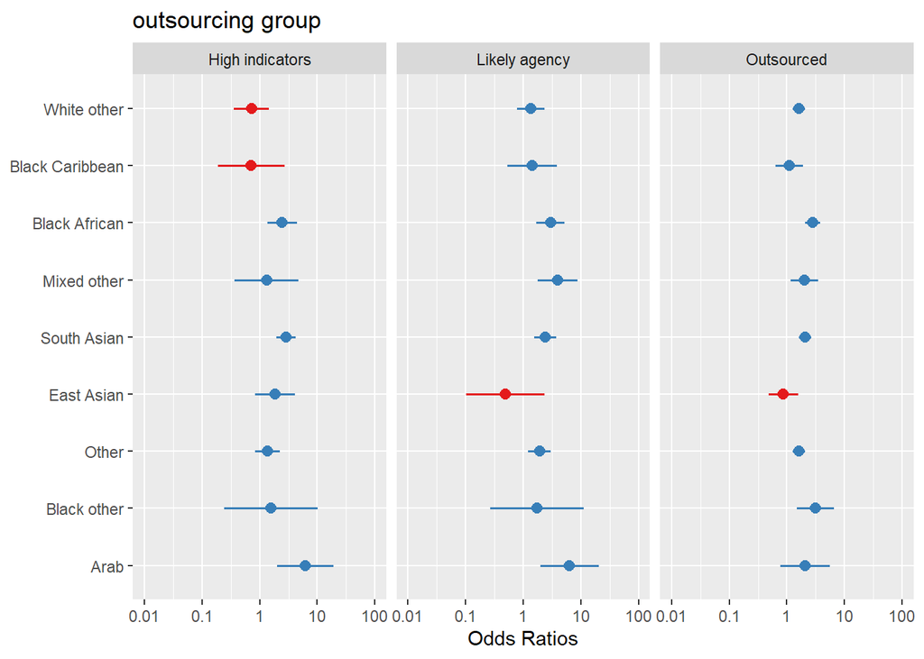

## Interaction: Ethnicity and gender

There does not appear to be any compelling ethnicity by gender interaction. There is a marginally significant effect indicating that East Asian men, but not East Asian women, are less likely to be outsourced than their White British counterparts.

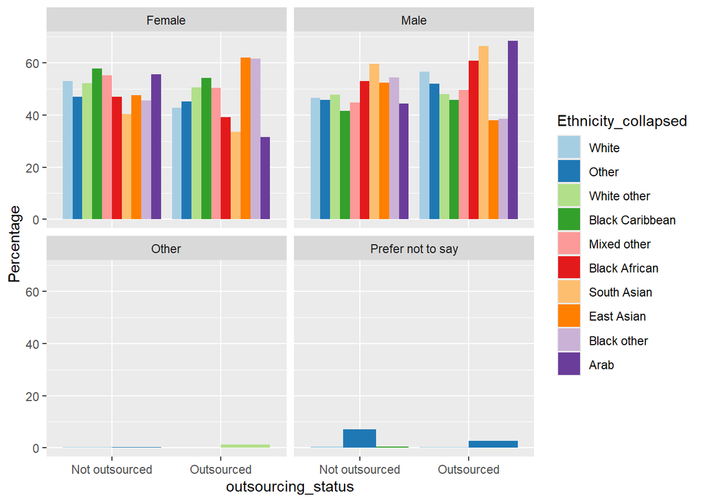

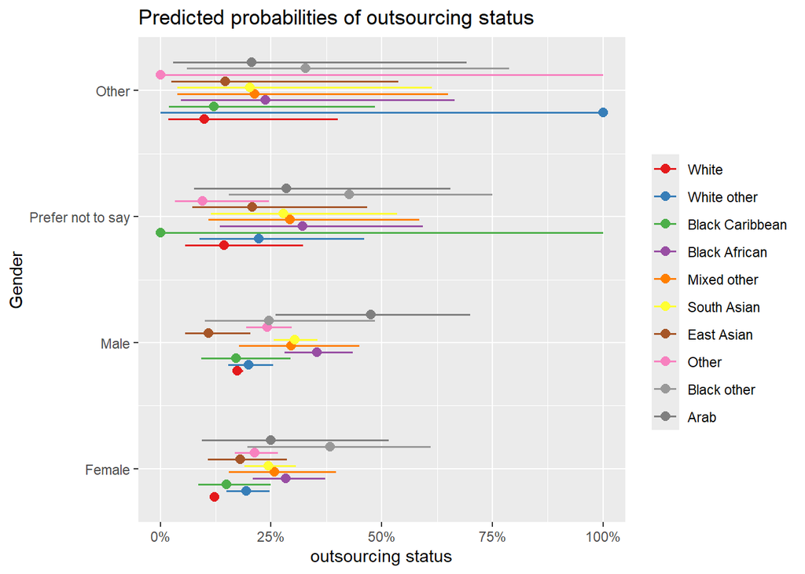

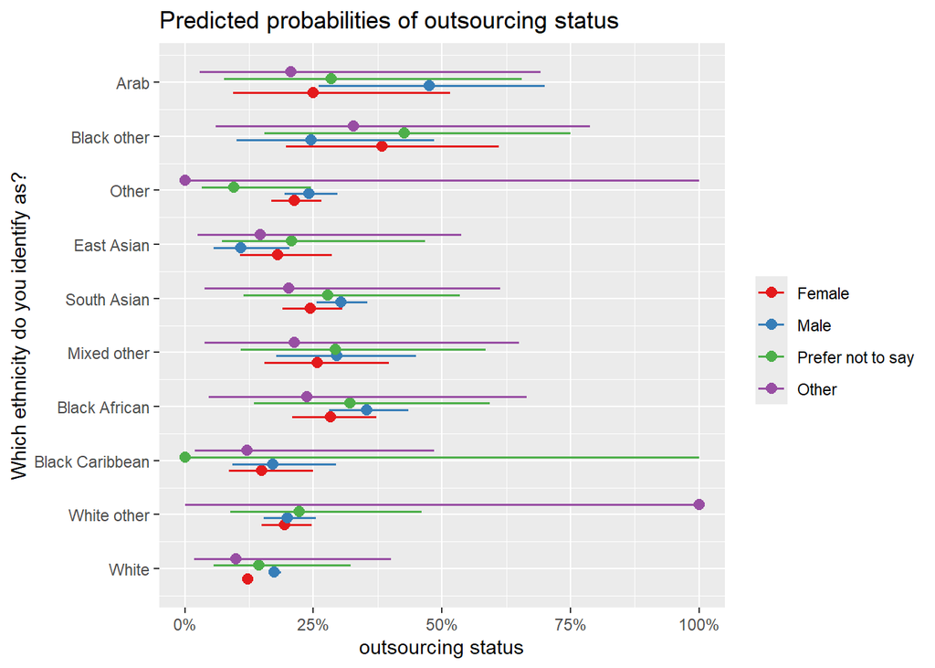

## Arrival in the UK

As for non-outsourced workers, the vast majority of outsourced workers are born in the UK. However, people not born in the UK are more likely to be outsourced than people born in the UK. 24.13% of outsourced workers are not born in the UK, compared to 14.08% of non-outsourced workers.[^10] This difference is statistically significant; **outsourced workers are 1.94 times more likely to have been born outside the UK than non-outsourced workers.**[^11]

**Note**

This variable is worded a little strangely, e.g. responses are things like “within the last 10 years”, “within the last 15 years”. Given that respondents only give one answer to this question, I think we can assume that the responses are basically brackets. That is, someone responding “within the last 15 years” is basically saying “I came to the UK between 11 and 15 years ago”.

Looking at the figure below, compared to non-outsourced people, there is a larger proportion of outsourced workers for each arrival time apart from ‘Within the last 30 years’.

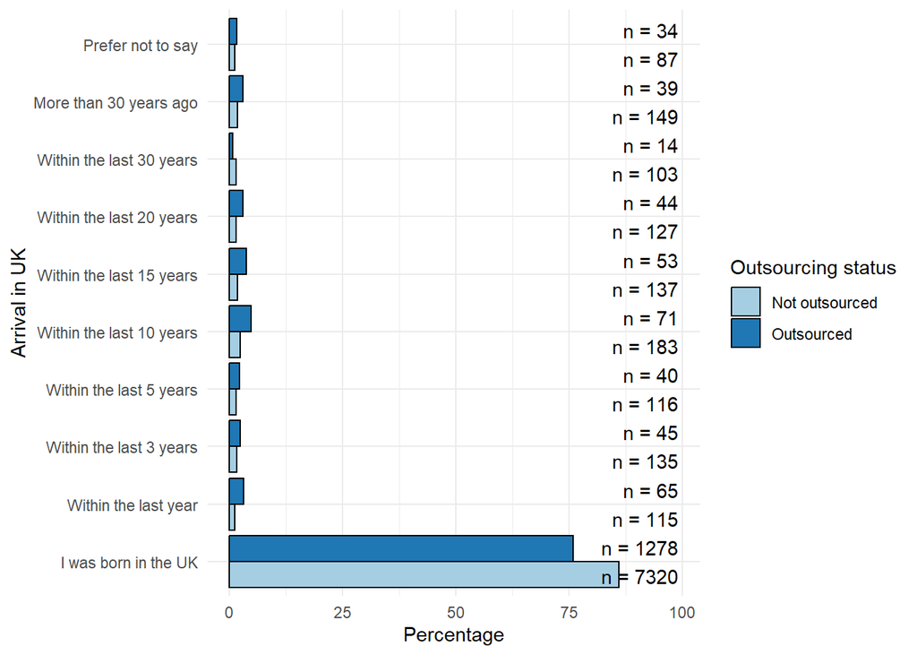

Exploring *types* of outsourced work indicates that the pattern observed above applies evenly to the different outsourcing groups.[^12] Compared to people born in the UK, people not born in the UK are:

- 1.97 times more likely to be outsourced than non-outsourced
- 1.82 times more likely to be likely agency than non-outsourced
- 1.93 times more likely to be high indicators than non-outsourced

The figure below indicates that the proportion of workers of each outsourcing group within each arrival time are broadly similar.

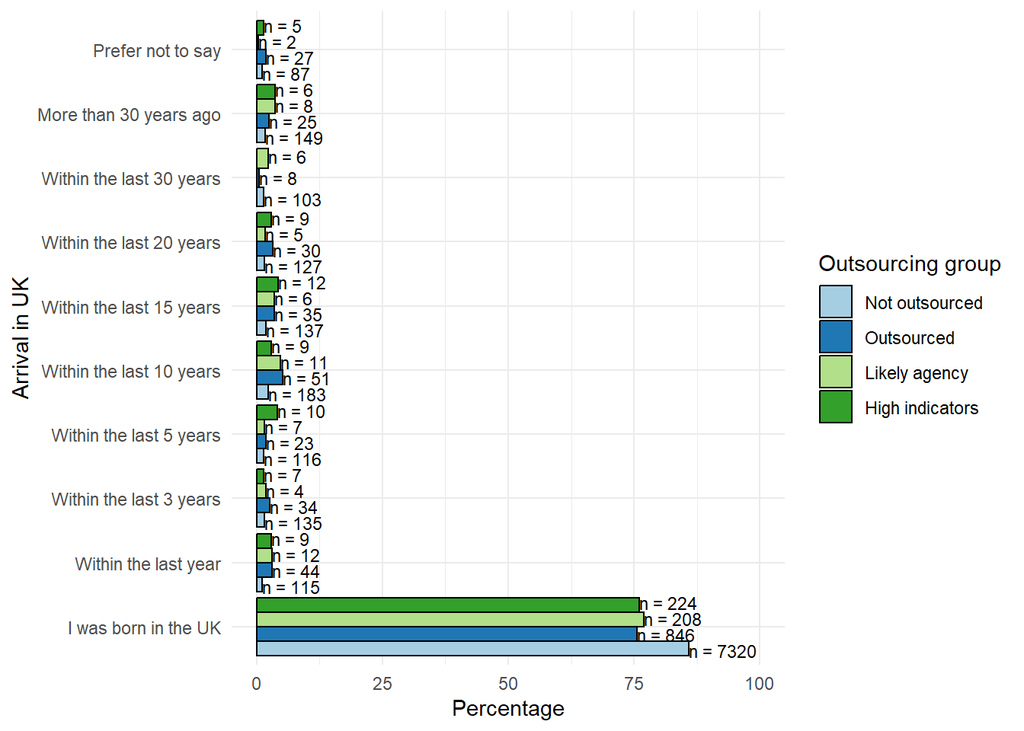

## Interaction: Ethnicity and arrival time

```
Analysis of Deviance Table

Model 1: outsourcing_status ~ Ethnicity_collapsed + BORNUK_binary
Model 2: outsourcing_status ~ Ethnicity_collapsed * BORNUK_binary
  Resid. Df Resid. Dev Df Deviance     F  Pr(>F)
1     10144     9036.1
2     10135     9011.6  9   24.456 2.712 0.00373 **
---
Signif. codes:  0 '***' 0.001 '**' 0.01 '*' 0.05 '.' 0.1 ' ' 1
```

Exploring the intersection of ethnicity and arrival time reveals some patterns whereby the likelihood of a person being outsourced is related to the combinations of ethnicity and whether they were born in the UK.[^13] The plot below shows that

- Among workers born in the UK, a Black African worker is 2.73 times more likely to be outsourced than a White worker.
- Among workers born in the UK, a South Asian worker is 2.42 times more likely to be outsourced than a White worker.
- Among workers not born in the UK, a Black African worker is 1.97 times more likely to be outsourced than a White other worker.

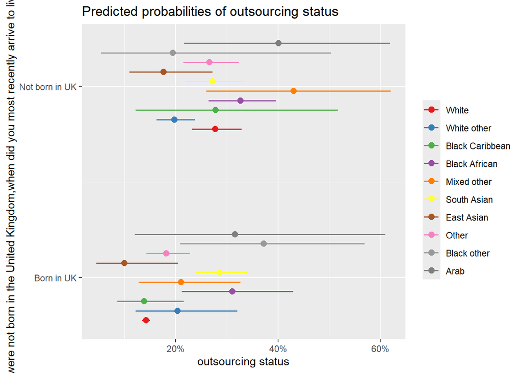

Similarly, the plot below shows that[^14]

- Among White workers, someone not born in the UK is 2.32 times more likely to be outsourced than someone born in the UK.
- Among Mixed other workers, someone not born in the UK is 2.84 times more likely to be outsourced than someone born in the UK.
- Among Other workers, someone not born in the UK is 1.64 times more likely to be outsourced than someone born in the UK.

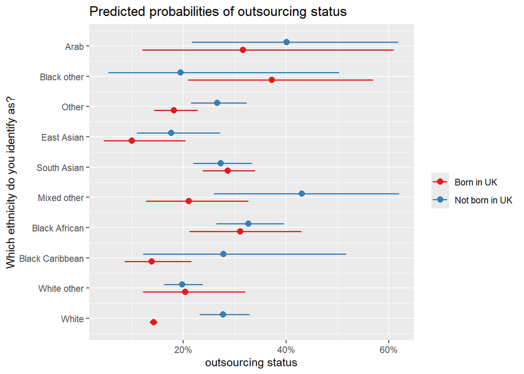

Put differently, being born in the UK is relevant in predicting outsourcing status only for White, Mixed other, and Other ethnicities. For other ethnicities, it doesn’t matter whether you are born in the UK or not. And compared to a White person born in the UK, Black African and South Asian workers are more likely to be outsourced whether or not they were born in the UK.

Overall, this pattern of results paints a racialised picture with strong colonial undertones. UK-born Black African and South Asian workers are more likely than UK-born White workers to be outsourced. For these and most other non-White groups, being born in the UK is not relevant for predicting outsourcing status; a Black African is just as likely to be outsourced if they arrived in the UK today than if they were born in the UK. However, the story is not one only of race. Non-UK-born White people are more likely to be outsourced than UK-born White people.

In summary, people born in the UK are more likely to be outsourced if they are Black African or South Asian compared to White, and White and (mixed) other ethnicities are more likely to be outsourced if they are not born in the UK compared to if they were born in the UK.

We next explore arrival time by collapsing responses to the arrival time question into fewer categories as below

Collapsed level

Original level

Born in UK

- I was born in the UK

Came to UK recently

- Within the last year
- Within the last 3 years
- Within the last 5 years
- Within the last 10 years

Came to UK not recently

- Within the last 15 years
- Within the last 20 years
- Within the last 30 years
- More than 30 years ago

Prefer not to say

- Prefer not to say

Exploring these categories[^15] confirms that

- Among workers born in the UK, a Black African worker is 2.73 times more likely to be outsourced than a White worker.
- Among workers born in the UK, a South Asian worker is 2.42 times more likely to be outsourced than a White worker.

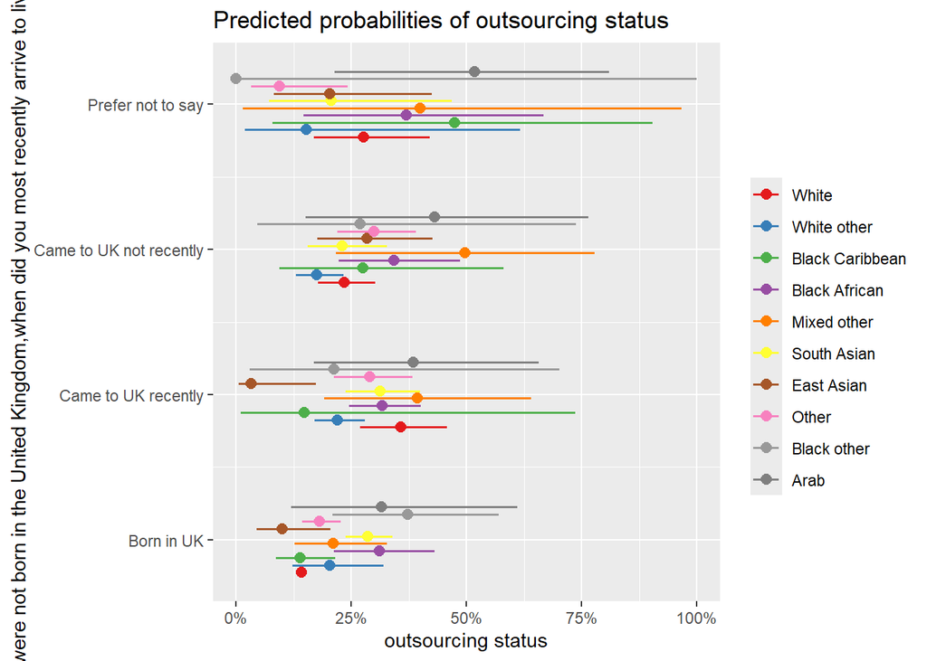

And[^16]

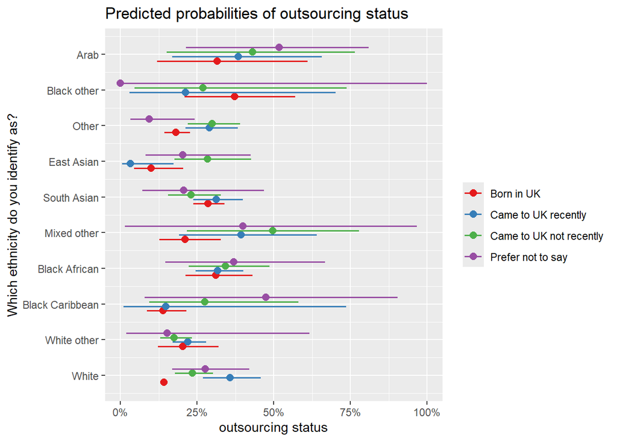

In summary,

- White outsourced workers are more likely to have not been born in the UK
- East Asian and Other outsourced workers are more likely to have been in the UK a longer time (10 years plus)
- UK-born Black African and South Asian workers are more likely to be outsourced than White UK-born workers, but no more or less likely to be outsourced than non-UK born Black African and South Asian workers (revise this)

# Characteristics of outsourced work

## Sectors

Here we explore what proportion of workers in each sector are outsourced.[^17]

The plot below shows the proportion of outsourced and not outsourced workers within each sector. I.e. this is showing what sectors have higher and lower proportions of outsourced workers.

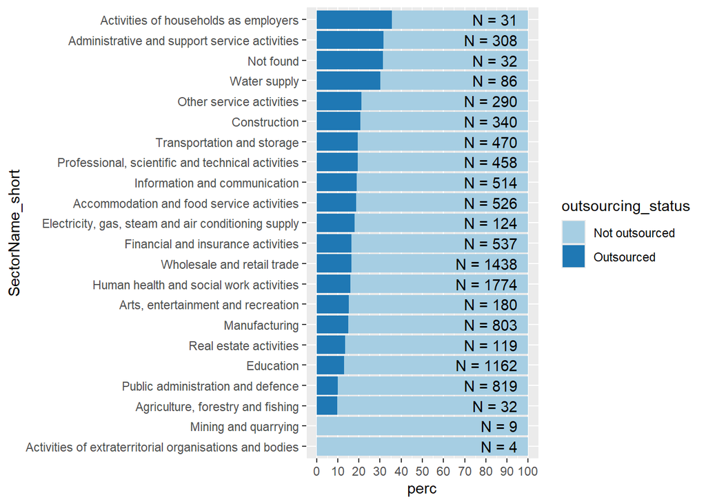

- ACTIVITIES OF HOUSEHOLDS AS EMPLOYERS; UNDIFFERENTIATED GOODS-AND SERVICES-PRODUCING ACTIVITIES OF HOUSEHOLDS FOR OWN US (note that N = 31)
- ADMINISTRATIVE AND SUPPORT SERVICE ACTIVITIES
- WATER SUPPLY; SEWERAGE, WASTE MANAGEMENT AND REMEDIATION ACTIVITIES

Note that for an undefined sector (‘Not found’) contained one of the largest proportions of outsourced workers (31% of workers in the ‘Not found’ category were outsourced).

A key takeaway here is that whereas the total outsourced population is 17%, this figure varies by sector, from 0% for Mining… and Extraterritoral organisations… all the way to 36% for Activities of households as employers, with 5 out 20 sectors having at least 20% of their workforce outsourced.

To test what sectors are more likely to employ outsourced workers, it is necessary to choose a “reference” sector against which to compare other sectors. A priori there is no theoretical candidate sector that should be the reference. However, we can select a reference based on what we know about the proportion of workers in each sector. One strategy is to choose the sector that has the lowest proportion of outsourced workers. Doing so means that interpretation is something along the lines of

“compared to the sector that we know has the smallest outsourced workforce, a worker is *x* times more likely to be outsourced if they work in Sector A”

From the figure above we can see that the sectors with the lowest proportion of outsourced workers are “Mining…” and “Activities of extraterritorial…”, which both have zero outsourced workers. A problem with using these is that the sample sizes are very small. The next-lowest is “Agriculture…”, but here the sample is quite small too. The next-lowest is “Public administration and defence”, which has an outsourced workforce of around **10%** and a sample size of **819**. This is probably the best candidate as a reference, because it has a reliable sample size and offers a low outsourcing baseline against which to compare other sectors. It is also quite neat that this sector is basically civil service, which also distinguishes it from other sectors.

```
Call:
glm(formula = outsourcing_status ~ SectorName_short, family = "quasibinomial",
    data = data, weights = NatRepemployees)

Coefficients:
                                                                         Estimate
(Intercept)                                                              -2.19156
SectorName_shortAccommodation and food service activities                 0.72447
SectorName_shortActivities of extraterritorial organisations and bodies -11.36997
SectorName_shortActivities of households as employers                     1.60107
SectorName_shortAdministrative and support service activities             1.41796
SectorName_shortAgriculture, forestry and fishing                        -0.03838
SectorName_shortArts, entertainment and recreation                        0.47682
SectorName_shortConstruction                                              0.84169
SectorName_shortEducation                                                 0.29638
SectorName_shortElectricity, gas, steam and air conditioning supply       0.67577
SectorName_shortFinancial and insurance activities                        0.57223
SectorName_shortHuman health and social work activities                   0.53613
SectorName_shortInformation and communication                             0.74377
SectorName_shortManufacturing                                             0.45222
SectorName_shortMining and quarrying                                    -11.40747
SectorName_shortNa                                                        0.01174
SectorName_shortNot found                                                 1.40625
SectorName_shortOther service activities                                  0.87279
SectorName_shortProfessional, scientific and technical activities         0.76539
SectorName_shortReal estate activities                                    0.33445
SectorName_shortTransportation and storage                                0.76835
SectorName_shortWater supply                                              1.34468
SectorName_shortWholesale and retail trade                                0.56088
                                                                        Std. Error
(Intercept)                                                                0.12153
SectorName_shortAccommodation and food service activities                  0.15973
SectorName_shortActivities of extraterritorial organisations and bodies  279.82847
SectorName_shortActivities of households as employers                      0.34812
SectorName_shortAdministrative and support service activities              0.16843
SectorName_shortAgriculture, forestry and fishing                          0.55101
SectorName_shortArts, entertainment and recreation                         0.24042
SectorName_shortConstruction                                               0.18066
SectorName_shortEducation                                                  0.15172
SectorName_shortElectricity, gas, steam and air conditioning supply        0.26284
```

[output cut: 81 more lines]

```
SectorName_shortReal estate activities
SectorName_shortTransportation and storage                              ***
SectorName_shortWater supply                                            ***
SectorName_shortWholesale and retail trade                              ***
---
Signif. codes:  0 '***' 0.001 '**' 0.01 '*' 0.05 '.' 0.1 ' ' 1

(Dispersion parameter for quasibinomial family taken to be 1.001064)

    Null deviance: 9201.5  on 10153  degrees of freedom
Residual deviance: 9065.1  on 10131  degrees of freedom
  (1 observation deleted due to missingness)
AIC: NA

Number of Fisher Scoring iterations: 12
```

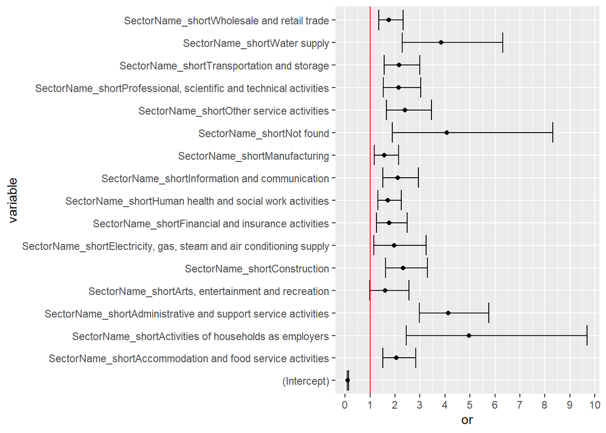

Exploring this by type of outsourced worker shows that for all sectors, the majority of outsourced workers fall into the ‘outsourced’ group.[^18]

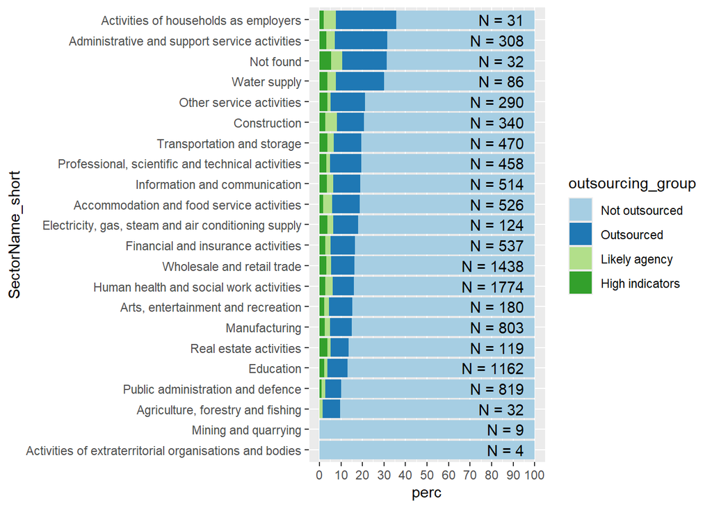

In contrast, sectors with high proportion ‘high indicators’ relative to likely agency are:

- Other service activities
- Professional, scientific and technical activities
- Real estate activities

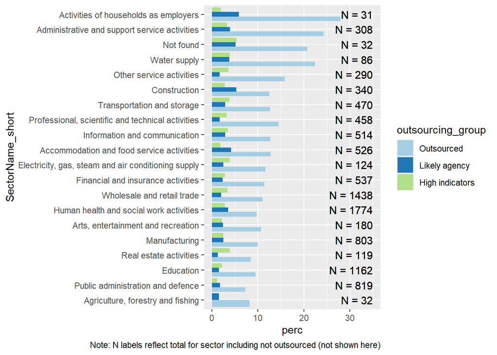

## Pay

**Note**

Note, the total sample on which income analysis is based is 8943.

The number of income data points for the outsourced group is 1512

The number of income data points for the not outsourced group is 7431

The table and plot below show descriptive statistics on income and its distribution for outsourced and non-outsourced people. Regression analysis shows that **outsourced workers are on average paid £2048 less than non-outsourced workers**.[^19]

| Outsourcing group | n | Mean | Median | Min | Max | Standard dev. |
| --- | --- | --- | --- | --- | --- | --- |
| Not outsourced | 6925 | 27106.73 | 25200.5 | 2000 | 66669 | 13309.13 |
| Outsourced | 1366 | 25058.37 | 24000.0 | 2400 | 66108 | 13022.18 |

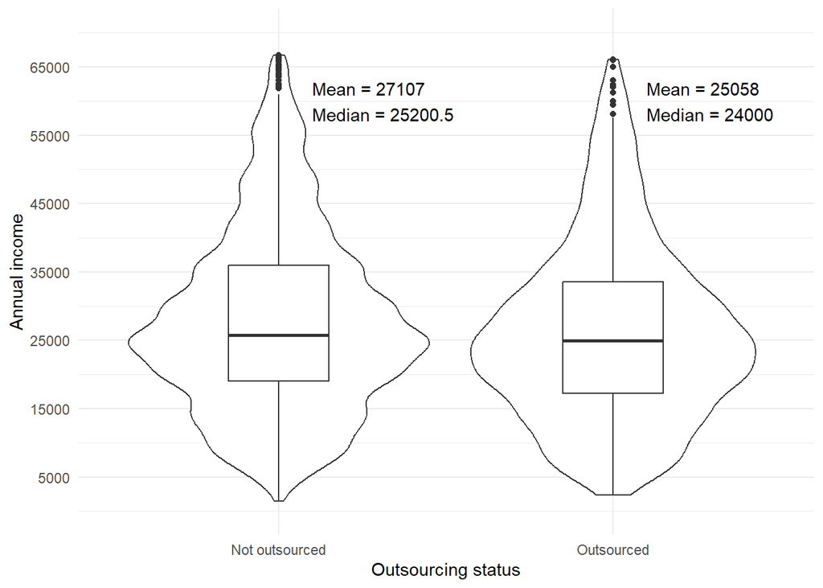

This difference increases to £2954 when we take into account Age, Gender, Ethnicity, Region, and Arrival Time. [^20] This analysis shows that all other variables, apart from Age, are in some way relevant to income. On average,

- Men earn £6592 more than women.
- East Asian workers earn £6064 more than White British workers.
- Workers in all non-London regions earn less than workers in London
  - East Midlands: -£6549
  - East of England: -£4563
  - North East: -£5291
  - North West: -£4932
  - Northern Ireland: -£7192
  - Scotland: -£4959
  - South East: -£3940
  - Wales: -£5430
  - West Midlands: -£5764
  - Yorkshire and the Humber: -£6042
- People who arrived in the UK within the last year earn £3868 less than people born in the UK
- People who arrived within the last 30 years earn £3489 more than people born in the UK.

Notable takeaways:

- There is a substantial gender pay gap present in the data
- The South East is the highest-paid region after London. Northern Ireland is the lowest paid region.
- People who have very recently arrived in the UK are paid less than people who were born in the UK, whilst people who migrated to the UK a long time ago earn more than people born in the UK.

Next we explore differences by outsourcing group. The table and plot below show descriptive statistics on income and its distribution for outsourced groups. Regression analysis shows that **outsourced workers are on average paid £2987 less than non-outsourced workers**, while no differences are evident for the likely agency and high indicators groups.[^21]

| Outsourcing group | n | Mean | Median | Min | Max | Standard dev. |
| --- | --- | --- | --- | --- | --- | --- |
| Not outsourced | 6925 | 27106.73 | 25200.50 | 2000.00 | 66669.00 | 13309.13 |
| Outsourced | 896 | 24120.18 | 23000.00 | 2400.00 | 66000.00 | 12808.78 |
| Likely agency | 231 | 25639.33 | 23095.97 | 3569.28 | 65846.67 | 13754.83 |
| High indicators | 239 | 28286.45 | 27000.00 | 4644.00 | 65000.00 | 12631.89 |

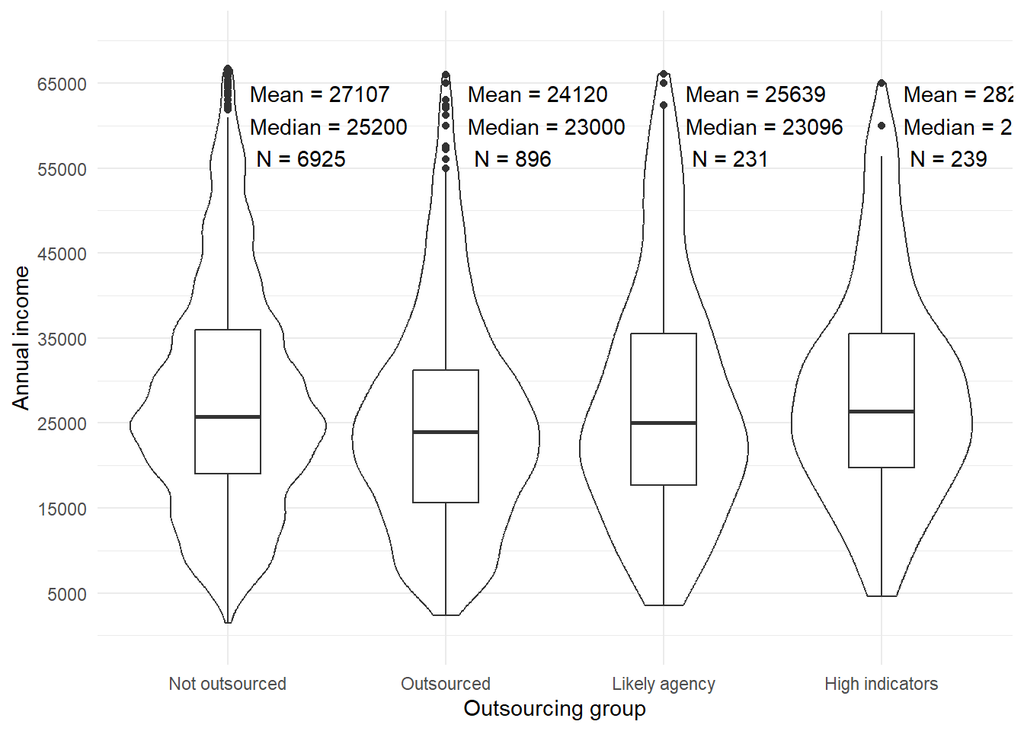

However, when controlling, as before, for Age, Gender, Ethnicity, Arrival Time, and Region,[^22] we find

- the outsourced group on average earns **£3643 less** than the non-outsourced group, and
- the likely agency group on average earns **£2272 less** than the non-outsourced group

In addition to showing that likely agency workers receive lower pay than the non-outsourced workers, this analysis reveals that “pure outsourced” workers’ pay is even lower, and that the estimate we obtained in the analysis above considering only status is a diluted effect averaging the outsourced and likely agency pay gaps.

## Footnotes

[^1]: outputs/data/total_outsourced.csv
[^2]: outputs/data/total_outsourced_2.csv
[^3]: outputs/data/age_stats.csv
[^4]: outputs/data/age_stats_2.csv
[^5]: outputs/data/sector_summary_3.csv
[^6]: [../outputs/data/gender_inferential_tab.csv](https://github.com/Project-X-UK/jrf_nat_rep/blob/main/outputs/data/gender_inferential_tab.csv)
[^7]: outputs/data/ethnicity_stats_1.csv & outputs/data/ethnicity_binary_o-status_inferential_tab.csv
[^8]: outputs/data/ethnicity_model_inferential.csv
[^9]: outputs/data/ethnicity_ogroup_inferential_tab.csv
[^10]: outputs/data/arrival_in_UK_stats.csv
[^11]: outputs/data/bornuk_ostatus_inferential_tab.csv
[^12]: outputs/data/bornuk_ogroup_inferential_tab.csv & /outputs/data/arrival_in_UK_stats_2.csv
[^13]: outputs/data/bornUK_binary_contrasts.csv
[^14]: outputs/data/bornUK_binary_contrasts_2.csv
[^15]: outputs/data/bornUK_collapsed_contrasts.csv
[^16]: outputs/data/bornUK_collapsed_contrasts_2.csv
[^17]: outputs/data/sector_summary_3.csv
[^18]: outputs/data/sector_summary_o-group.csv
[^19]: outputs/data/income_stats_o-status.csv & outputs/data/model_income_by_o-status.csv
[^20]: outputs/data/model_2_income_by_o-status.csv
[^21]: outputs/data/income_stats_o-group.csv & outputs/data/model_income_by_o-group.csv
[^22]: outputs/data/model_2_income_by_o-group.csv